# MUSA508 Bike Share Rebalancing in Washington, D.C.

### 5.3 Cross Validation

```r
fitControl <- caret:: trainControl(method = "cv",
                                   number = 10,
                                   savePredictions = TRUE)

set.seed(717)

reg1.cv <-
  caret::train(Trip_Count ~ ., data = ride.panel %>%
                 dplyr::select(Trip_Count, interval60, dotw , Temperature , Precipitation , Wind_Speed , Med_Inc ,  Med_Age ,  Mean_Commute_Time , Percent_Taking_Public_Trans ,  metro_nn1 , metro_nn2 , grocery_nn1 , grocery_nn2) ,
               method = "lm",
               trControl = fitControl,
               na.action = na.pass)

kable(reg1.cv$resample) %>%
  kable_styling(font_size = 12, full_width = F,
                bootstrap_options = c("striped", "hover", "condensed")) %>%
  footnote(general = "Table 5.1 Cross-validation Test on Model 1: Summary of RMSE, R Squared and MAE\n",
           general_title= '\n')
```

| RMSE | Rsquared | MAE | Resample |
| --- | --- | --- | --- |
| 0.0501636 | 0.0001310 | 0.0036701 | Fold01 |
| 0.0380371 | 0.0000678 | 0.0031838 | Fold02 |
| 0.0694172 | 0.0002979 | 0.0039842 | Fold03 |
| 0.0576087 | 0.0006870 | 0.0035147 | Fold04 |
| 0.1000711 | 0.0017033 | 0.0039193 | Fold05 |
| 0.0450967 | 0.0001137 | 0.0038390 | Fold06 |
| 0.0387222 | 0.0002460 | 0.0032275 | Fold07 |
| 0.0527696 | 0.0001793 | 0.0035265 | Fold08 |
| 0.0373173 | 0.0001831 | 0.0032516 | Fold09 |
| 0.0414038 | 0.0000019 | 0.0035215 | Fold10 |

Table 5.1 Cross-validation Test on Model 1: Summary of RMSE, R Squared and MAE

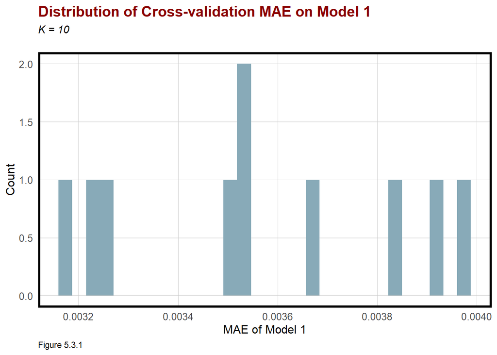

```r
ggplot(data = reg1.cv$resample) +
  geom_histogram(aes(x = reg1.cv$resample$MAE), fill = '#88aab8') +
  labs(title="Distribution of Cross-validation MAE on Model 1",
       subtitle = "K = 10\n",
       caption = "Figure 5.3.1 ") +
  xlab('MAE of Model 1') +
  ylab('Count') +
  plotTheme()
```

```r
reg4.cv <-
  caret::train(Trip_Count ~ ., data = ride.panel %>%
                 dplyr::select(Trip_Count, start_station_name,interval60, dotw , Temperature , Precipitation , Wind_Speed , Med_Inc ,  Med_Age ,  Mean_Commute_Time , Percent_Taking_Public_Trans ,  metro_nn1 , metro_nn2 , grocery_nn1 , grocery_nn2 ,
                   lagHour , lag2Hours ,lag3Hours , lag12Hours , lag1day) ,
               method = "lm",
               trControl = fitControl,
               na.action = na.pass)


kable(reg4.cv$resample) %>%
  kable_styling(font_size = 12, full_width = F,
                bootstrap_options = c("striped", "hover", "condensed")) %>%
  footnote(general = "Table 5.2. Cross-validation Test on Model 4: Summary of RMSE, R Squared and MAE\n",
           general_title= '\n')
```

| RMSE | Rsquared | MAE | Resample |
| --- | --- | --- | --- |
| 0.0365032 | 0.0023376 | 0.0031095 | Fold01 |
| 0.0502414 | 0.0074009 | 0.0038990 | Fold02 |
| 0.0407899 | 0.0000392 | 0.0034911 | Fold03 |
| 0.0415637 | 0.0000995 | 0.0035788 | Fold04 |
| 0.0561904 | 0.0198370 | 0.0034580 | Fold05 |
| 0.0417301 | 0.0227899 | 0.0034276 | Fold06 |
| 0.0545024 | 0.0013299 | 0.0036813 | Fold07 |
| 0.0995913 | 0.1083535 | 0.0041574 | Fold08 |
| 0.0588255 | 0.0006548 | 0.0036825 | Fold09 |
| 0.0571165 | 0.0035832 | 0.0035673 | Fold10 |

Table 5.2. Cross-validation Test on Model 4: Summary of RMSE, R Squared and MAE

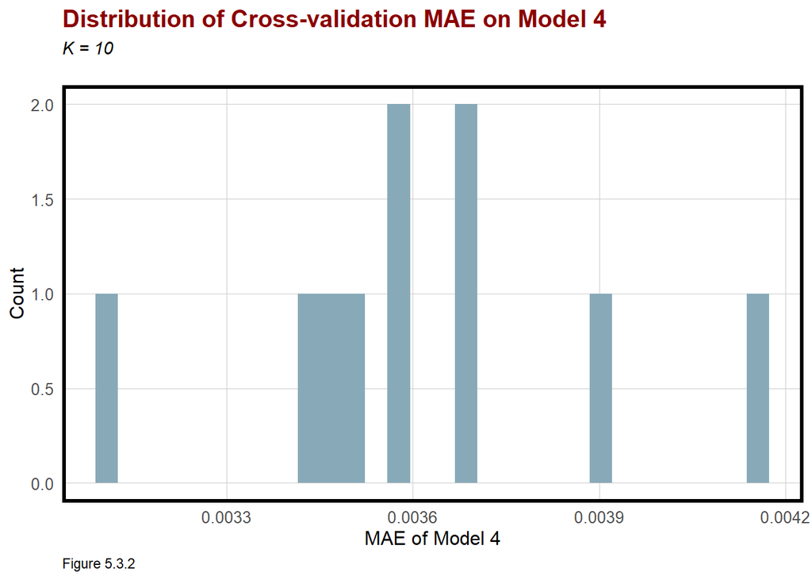

```r
ggplot(data = reg4.cv$resample) +
  geom_histogram(aes(x = reg4.cv$resample$MAE), fill = '#88aab8') +
  labs(title="Distribution of Cross-validation MAE on Model 4",
       subtitle = "K = 10\n",
       caption = "Figure 5.3.2 ") +
  xlab('MAE of Model 4') +
  ylab('Count') +
  plotTheme()
```

## VI. Conclusion

Overall, the current algorithm need refinements before applying to bike share re-balancing plan. First, it’s not clear how the COVID-19 pandemic affect users bike share trips. Before the pandemic is under control, outdoor activities were overall discouraged while people prefer cycling over walking as a safer exercise. Second, when analyzing trip count at small unit (hour), there is no sufficient data to support the analysis, most data being 1 or 0 is not helping. This ties to the third improvement, that despite the minor error rate of the model, the model is not doing a good job at predicting existing data.